# Ajusting the graph

2643018s

2025-02-07

```r
library(tidyverse)
library(lmerTest)
data <- read_csv("task_error_data.csv") %>%
  na.omit()
```

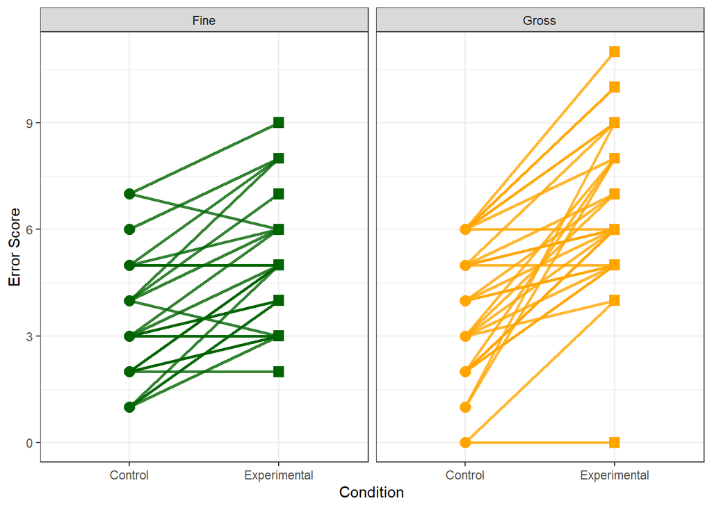

```r
data_long <- data %>%
  pivot_longer(cols = c(FC_error, FM_error, GC_error, GM_error),
               names_to = "temp",
               values_to = "error") %>%
  mutate(
    group = if_else(str_detect(temp, "F"), "Fine", "Gross"),
    condition = if_else(str_detect(temp, "C"), "Control", "Experimental")
  ) %>%
  select( - temp)

rdata_long <- data_long %>%
  pivot_wider(names_from = condition, values_from = error)


# Assuming 'data_long' has the following columns:
# participant, group (with values "Fine" or "Gross"),
# condition (with values "Control" or "Experimental"), and error

scatter_combined <- ggplot(data_long, aes(x = condition, y = error, group = Participants, color = group)) +
  geom_line(size = 1, alpha = 0.8) +
  geom_point(aes(shape = condition), size = 3, stroke = 1) +
  facet_wrap(~ group) +
  theme_bw() +
  scale_shape_manual(values = c("Control" = 16, "Experimental" = 15)) +  # 16 = circle, 15 = square
  scale_color_manual(values = c("Fine" = "darkgreen", "Gross" = "orange")) +
  labs(#title = "Paired Observations by Group",
       x = "Condition",
       y = "Error Score") +
  theme(legend.position = "none")
scatter_combined
```

```r
model_poisson <- glmer(
  error ~ group * condition + (1 | Participants),
  data = data_long,
  family = poisson(link = "log")
)
summary(model_poisson)
```

```
## Generalized linear mixed model fit by maximum likelihood (Laplace
##   Approximation) [glmerMod]
##  Family: poisson  ( log )
## Formula: error ~ group * condition + (1 | Participants)
##    Data: data_long
##
##      AIC      BIC   logLik deviance df.resid
##    531.7    545.9   -260.8    521.7      123
##
## Scaled residuals:
##      Min       1Q   Median       3Q      Max
## -2.28277 -0.56120 -0.02399  0.61686  1.75246
##
## Random effects:
##  Groups       Name        Variance Std.Dev.
##  Participants (Intercept) 0.03019  0.1737
## Number of obs: 128, groups:  Participants, 32
##
## Fixed effects:
##                                  Estimate Std. Error z value Pr(>|z|)
## (Intercept)                        1.1636     0.1031  11.290  < 2e-16 ***
## groupGross                         0.1178     0.1345   0.875  0.38135
## conditionExperimental              0.3990     0.1265   3.153  0.00161 **
## groupGross:conditionExperimental   0.1954     0.1710   1.143  0.25311
## ---
## Signif. codes:  0 '***' 0.001 '**' 0.01 '*' 0.05 '.' 0.1 ' ' 1
##
## Correlation of Fixed Effects:
##             (Intr) grpGrs cndtnE
## groupGross  -0.691
## cndtnExprmn -0.735  0.563
## grpGrss:cnE  0.544 -0.787 -0.740
```

Hypothesis 1:

A significant main effect of condition was found, B = 0.40, SE = 0.13, z = 3.15, p = .002, indicating that participants in the Experimental condition made significantly more errors compared to the Control condition.

B = 0.40, SE = 0.13, z = 3.15, p = .002 This means that for Fine tasks, the Experimental condition led to significantly more errors compared to the Control condition. Gross Motor Tasks:

B = 0.40 + 0.20 = 0.60, SE ≈ 0.21, z ≈ 2.86, p ≈ .004 This suggests that the Experimental condition increased error rates more for Gross than for Fine, though the interaction was not significant.

Hypothesis 2:

The main effect of group (Fine vs. Gross) was not significant, B = 0.12, SE = 0.13, z = 0.88, p = .38, suggesting that overall error rates did not significantly differ between Fine and Gross motor tasks.

The interaction term also showed a moderate correlation with both group (r = -0.79) and condition (r = -0.74), though these were not significant effects in the model.

Random Effects

A random intercept for Participants was included to account for individual differences, which had a variance of 0.03 (SD = 0.17). This suggests that between-subject variability in error rates was minimal.

```r
set.seed(21)

# Assume rdata_long has columns: Participants, group, Control, Experimental
# Split data into Fine and Gross groups
rdata_fine <- rdata_long %>% filter(group == "Fine")
rdata_gross <- rdata_long %>% filter(group == "Gross")

# Define bootstrap parameters
nboot <- 10000
np_fine <- nrow(rdata_fine)
np_gross <- nrow(rdata_gross)

# Function to perform hierarchical bootstrap for one group
bootstrap_group <- function(data, np, nboot) {
  # Create a matrix of bootstrap indices for participants
  bootid <- matrix(sample(np, np * nboot, replace = TRUE), nrow = nboot)
  # Allocate a matrix to store bootstrap results:
  # Column 1: 20% trimmed mean for Control,
  # Column 2: 20% trimmed mean for Experimental,
  # Column 3: 20% trimmed mean difference (Experimental - Control)
  bootres <- matrix(NA, nrow = nboot, ncol = 3)

  for (B in 1:nboot) {
    # Sample participants with replacement for this bootstrap iteration
    boot_sample <- data[bootid[B, ], ]
    # Compute the 20% trimmed means for Control and Experimental conditions
    boot_control <- mean(boot_sample$Control, trim = 0.2)
    boot_experimental <- mean(boot_sample$Experimental, trim = 0.2)
    boot_diff <- boot_experimental - boot_control
    # Store the results
    bootres[B, 1] <- boot_control
    bootres[B, 2] <- boot_experimental
    bootres[B, 3] <- boot_diff
  }
  return(bootres)
}

# Run bootstrap for each group
bootres_fine <- bootstrap_group(rdata_fine, np_fine, nboot)
bootres_gross <- bootstrap_group(rdata_gross, np_gross, nboot)

# Compute the between-group difference for each bootstrap iteration:
# Difference (Fine - Gross) for each measure:
bootres_between <- cbind(
  Control_Diff = bootres_fine[, 1] - bootres_gross[, 1],
  Experimental_Diff = bootres_fine[, 2] - bootres_gross[, 2],
  Difference_Diff = bootres_fine[, 3] - bootres_gross[, 3]
)

# I dont want this ^ I want it so that its Fine_diff = bootres_experiental - bootstres_control,
```

```r
# Summary statistics for Fine group difference (Experimental - Control)
fine_diff <- bootres_fine[, 3]
fine_trimmed_mean <- mean(fine_diff, trim = 0.2)
fine_sd <- sd(fine_diff)
fine_ci <- quantile(fine_diff, probs = c(0.025, 0.975), type = 6)
p_fine <- 2 * min(mean(fine_diff < 0), mean(fine_diff > 0))

# Summary statistics for Gross group difference (Experimental - Control)
gross_diff <- bootres_gross[, 3]
gross_trimmed_mean <- mean(gross_diff, trim = 0.2)
gross_sd <- sd(gross_diff)
gross_ci <- quantile(gross_diff, probs = c(0.025, 0.975), type = 6)
p_gross <- 2 * min(mean(gross_diff < 0), mean(gross_diff > 0))

# Summary statistics for the Between-Group Difference (Fine Difference - Gross Difference)
between_diff <- bootres_between[, 3]
between_trimmed_mean <- mean(between_diff, trim = 0.2)
between_sd <- sd(between_diff)
between_ci <- quantile(between_diff, probs = c(0.025, 0.975), type = 6)
p_between <- 2 * min(mean(between_diff < 0), mean(between_diff > 0))

# Print the results
cat("Fine Group Difference (20% trimmed):\n")
```

```
## Fine Group Difference (20% trimmed):
```

```r
cat("  Mean =", fine_trimmed_mean, "\n")
```

```
##   Mean = 1.571742
```

```r
cat("  SD   =", fine_sd, "\n")
```

```
##   SD   = 0.3003772
```

```r
cat("  95% CI =", fine_ci, "\n")
```

```
##   95% CI = 1 2.15
```

```r
cat("  p-value =", p_fine, "\n\n")
```

```
##   p-value = 0
```

```r
cat("Gross Group Difference (20% trimmed):\n")
```

```
## Gross Group Difference (20% trimmed):
```

```r
cat("  Mean =", gross_trimmed_mean, "\n")
```

```
##   Mean = 2.801558
```

```r
cat("  SD   =", gross_sd, "\n")
```

```
##   SD   = 0.4504787
```

```r
cat("  95% CI =", gross_ci, "\n")
```

```
##   95% CI = 1.95 3.7
```

```r
cat("  p-value =", p_gross, "\n\n")
```

```
##   p-value = 0
```

```r
cat("Between-Group Difference (20% trimmed):\n")
```

```
## Between-Group Difference (20% trimmed):
```

```r
cat("  Mean =", between_trimmed_mean, "\n")
```

```
##   Mean = -1.2274
```

```r
cat("  SD   =", between_sd, "\n")
```

```
##   SD   = 0.5403107
```

```r
cat("  95% CI =", between_ci, "\n")
```

```
##   95% CI = -2.3 -0.2
```

```r
cat("  p-value =", p_between, "\n")
```

```
##   p-value = 0.0198
```

```r
# Create data frames for the within-group bootstrap results
boot_df_fine <- data.frame(
  Estimate = bootres_fine[, 3],
  Measure = "Fine Difference"
)
boot_df_gross <- data.frame(
  Estimate = bootres_gross[, 3],
  Measure = "Gross Difference"
)

# Create a data frame for the between-group differences
boot_df_between <- data.frame(
  Estimate = bootres_between[, 3],
  Measure = "Between-Group Difference"
)

# Combine all into one data frame for plotting
boot_df_all <- bind_rows(boot_df_fine, boot_df_gross, boot_df_between)
boot_df_all$Measure <- factor(boot_df_all$Measure, levels = c("Fine Difference", "Gross Difference", "Between-Group Difference"))
```

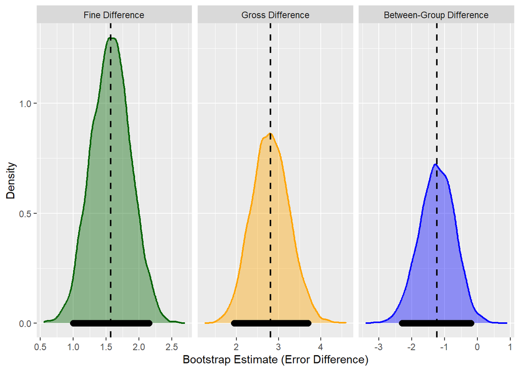

```r
# Calculate 95% confidence intervals
ci_df <- boot_df_all %>%
  group_by(Measure) %>%
  summarise(
    Mean = mean(Estimate),
    Lower_CI = quantile(Estimate, 0.025),
    Upper_CI = quantile(Estimate, 0.975)
  )

# Plot
ggplot(boot_df_all, aes(x = Estimate, color = Measure, fill = Measure)) +
  geom_density(size = 0.8, alpha = 0.4) +
  # Vertical line for mean
  geom_vline(data = ci_df, aes(xintercept = Mean), color = "black",
             linetype = "dashed", size = .8) +
  # Confidence intervals as horizontal segments
  geom_segment(data = ci_df, aes(x = Lower_CI, xend = Upper_CI, y = 0, yend = 0), color = "black",
               size = 3, lineend = "round") +
  facet_wrap(~ Measure, scales = "free_x") +
  scale_color_manual(values = c("Fine Difference" = "darkgreen",
                                "Gross Difference" = "orange",
                                "Between-Group Difference" = "blue")) +
  scale_fill_manual(values = c("Fine Difference" = "darkgreen",
                               "Gross Difference" = "orange",
                               "Between-Group Difference" = "blue")) +
  labs(#title = "Bootstrap Distributions of 20% Trimmed Means (Differences)",
       x = "Bootstrap Estimate (Error Difference)",
       y = "Density") +
  theme(legend.position = "none")
```